# Ensemble_Project_Bank

```
                            Ensemble Technique Project
```

Background :- This is a historical data of collected by Bank, which shows thier customer details. On basis of this historical details, we need to build a model which helps their tele marketing team to know about customer behavior and target those customer which have higher chances to take the term deposit subscription. By using this model tele marketing team can utilize thier effort in right direction. This will not only allow the bank to secure deposits more effectively but also increase customer satisfaction by reducing undesirable advertisements for certain customers.

Steps Taken :- 1 :- Import libraries, load data 2 :- Data Intuition (Understand the data structure, Glimps of Data) 3 :- Imputation (missing values and Outliers handling) 4 :- EDA (Exploratory Data Analysis) 5 :- Insight Reports, Visual Graphics 6 :- Transforming categorical veriable in dummies 7 :- Split the dataset in training and test dataset 8 :- Scaling the dataset 9 :- Model building 10:- Model Tuning 11:- Confusion Matrix 12:- OOB Score Calculation 13:- Stacking 14:- Final Score prediction 15:- Selecting high score feature and making model on it 16:- Summary 17:- Conclusion 18:- Suggession

Attributes :-

1 - age (numeric), in Years 2 - job : type of job (categorical: 'admin.','blue-collar','entrepreneur','housemaid','management','retired','self- employed','services','student','technician','unemployed','unknown') 3 - marital : marital status (categorical: 'divorced','married','single'; note: 'divorced' means divorced or widowed)

4 - education: (categorical: 'primary', 'secondary', 'tertiary', 'unknown') 5 - default: has credit in default? (Binary: 'no','yes') 6 - housing: has housing loan? (binary: 'no','yes') 7 - loan: has personal loan? (binary: 'no','yes')

8 - contact: contact communication type (categorical: 'cellular','telephone') 9 - month: last contact month of year (categorical: 'jan', 'feb', 'mar', ..., 'nov', 'dec') 10 - day: last contact day (categorical: 1,2 ,3 ,4 ......, 30, 31) 11 - duration: last contact duration, in seconds (numeric).

Output variable (desired target): 17 - Target - has the client subscribed a term deposit? (binary: 'yes','no')

```python
# import libraries
import numpy as np
import pandas as pd
import seaborn as sns
import matplotlib.pyplot as plt
%matplotlib inline
```

```python
# Load data
df = pd.read_csv('bank-full.csv')
```

```python
# Data Intuition (Understand the data structure, Glimps of Data)

df.head()
```

|  | age | job | marital | education | default | balance | housing | loan | contact | day | month | duration | campaign | pdays | previous | poutcome | Target |
| --- | --- | --- | --- | --- | --- | --- | --- | --- | --- | --- | --- | --- | --- | --- | --- | --- | --- |
| 0 | 58 | management | married | tertiary | no | 2143 | yes | no | unknown | 5 | may | 261 | 1 | -1 | 0 | unknown | no |
| 1 | 44 | technician | single | secondary | no | 29 | yes | no | unknown | 5 | may | 151 | 1 | -1 | 0 | unknown | no |
| 2 | 33 | entrepreneur | married | secondary | no | 2 | yes | yes | unknown | 5 | may | 76 | 1 | -1 | 0 | unknown | no |
| 3 | 47 | blue-collar | married | unknown | no | 1506 | yes | no | unknown | 5 | may | 92 | 1 | -1 | 0 | unknown | no |
| 4 | 33 | unknown | single | unknown | no | 1 | no | no | unknown | 5 | may | 198 | 1 | -1 | 0 | unknown | no |

```python
# min, max, Mean, Median, IQR, standard deviation etc details of numeric variables
df.describe().T
```

|  | count | mean | std | min | 25% | 50% | 75% | max |
| --- | --- | --- | --- | --- | --- | --- | --- | --- |
| age | 45211.0 | 40.936210 | 10.618762 | 18.0 | 33.0 | 39.0 | 48.0 | 95.0 |
| balance | 45211.0 | 1362.272058 | 3044.765829 | -8019.0 | 72.0 | 448.0 | 1428.0 | 102127.0 |
| day | 45211.0 | 15.806419 | 8.322476 | 1.0 | 8.0 | 16.0 | 21.0 | 31.0 |
| duration | 45211.0 | 258.163080 | 257.527812 | 0.0 | 103.0 | 180.0 | 319.0 | 4918.0 |
| campaign | 45211.0 | 2.763841 | 3.098021 | 1.0 | 1.0 | 2.0 | 3.0 | 63.0 |
| pdays | 45211.0 | 40.197828 | 100.128746 | -1.0 | -1.0 | -1.0 | -1.0 | 871.0 |
| previous | 45211.0 | 0.580323 | 2.303441 | 0.0 | 0.0 | 0.0 | 0.0 | 275.0 |

```python
# No null value in the dataset, also type of variables and total number or rows and columns
df.info()
```

```
<class 'pandas.core.frame.DataFrame'>
RangeIndex: 45211 entries, 0 to 45210
Data columns (total 17 columns):
age          45211 non-null int64
job          45211 non-null object
marital      45211 non-null object
education    45211 non-null object
default      45211 non-null object
balance      45211 non-null int64
housing      45211 non-null object
loan         45211 non-null object
contact      45211 non-null object
day          45211 non-null int64
month        45211 non-null object
duration     45211 non-null int64
campaign     45211 non-null int64
pdays        45211 non-null int64
previous     45211 non-null int64
poutcome     45211 non-null object
Target       45211 non-null object
dtypes: int64(7), object(10)
memory usage: 5.9+ MB
```

```python
# Imputation (missing values and Outliers handling)

df1 = pd.read_csv('bank-full.csv')
```

```python
# Dropping missing values in poutcome which is represented in dataset as 'other'
df2 = df1.drop(df1[df1['poutcome'] == 'other'].index, axis = 0, inplace=False)
```

```python
# Filling 'Unknown' in 'job' and 'education' with 'other' to make more sense of collected data.
df2[['job', 'education']] = df2[['job', 'education']].replace(['unknown'], 'other')
```

```
As data is not normally distributed and most of the variables has either left or right skew, hence we can analyse that outliers are also present in dataset.
```

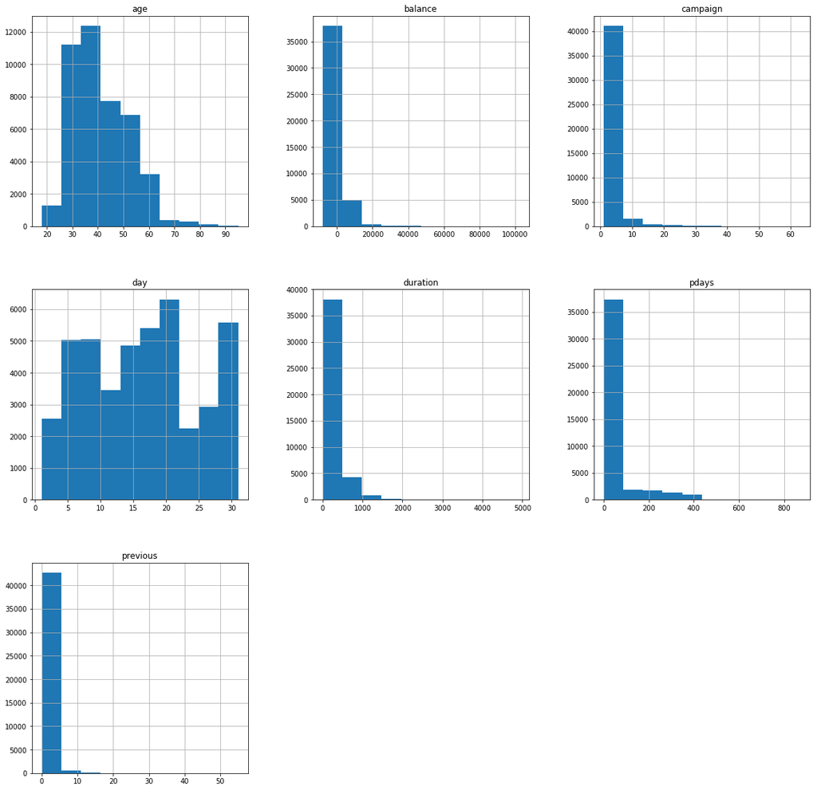

```python
# Using histogram to check the data distribution and skewness of variables.
df2.hist(figsize=(20,20))

print('As data is not normally distributed and most of the variables has either left or right skew, hence we can analyse that outliers are also present in dataset.')
```